# Dobór zmiennych do modelu (LASSO / SCAD / MCP)

```r
library(ncvreg)     # LASSO, SCAD, MCP w jednym pakiecie
library(nonprobsvy) # wersja >= 0.2.3 -- wspiera vars_selection
library(survey)
set.seed(2026)
```

# 1 Wprowadzenie

W tym notatniku pokazujemy jak **automatycznie** wybierać zmienne do modelu z wykorzystaniem regularyzacji L1 (LASSO) i kar niewypukłych (SCAD, MCP).

Po co? W praktyce mamy często **dużo** zmiennych pomocniczych (np. po zakodowaniu kategorycznych przez dummies), a tylko **niektóre** z nich są istotnie powiązane:

- z mechanizmem selekcji do próby nielosowej $R^A$,
- ze zmienną badaną $y$.

Zmienne nieistotne **zwiększają wariancję** estymatorów (IPW, MI, DR), a nie redukują obciążenia. Chcemy więc znaleźć rzadki (“sparse”) podzbiór ważnych zmiennych.

Trzy popularne funkcje kary:

- **LASSO** ($p_\lambda(x) = \lambda|x|$) – wypukła, szybka, ale obciąża duże współczynniki.
- **SCAD** – niewypukła, ma własność wyroczni (Fan, Li 2001).
- **MCP** – niewypukła, agresywniejsze odcinanie niż SCAD (Zhang 2010).

Plan notatnika:

1. Sztuczny przykład regresji liniowej – porównanie LASSO/SCAD/MCP w pakiecie `ncvreg`.
2. Sztuczny przykład z próbą nielosową i losową – dobór zmiennych w IPW przez `nonprobsvy`.
3. Realne dane `admin` i `jvs` – selekcja zmiennych w IPW, MI i DR.

# 2 Część A: Sztuczny przykład regresji liniowej

## 2.1 Generowanie danych

Tworzymy zbiór z $n = 200$ obserwacji i $p = 50$ zmiennych pomocniczych. Tylko **pięć** z nich ma niezerowy wpływ na $y$:

$$y_i = 3\,x_{i,1} + 1{,}5\,x_{i,2} + 2\,x_{i,5} - 2{,}5\,x_{i,10} + 1\,x_{i,20} + \varepsilon_i,$$

gdzie $\varepsilon_i \sim N(0, 1)$ a $\bx_i \sim N(\mathbf{0}, \mathbf{I}_{50})$.

```r
n <- 200
p <- 50
X <- matrix(rnorm(n*p), n, p)

# wektor prawdziwych współczynników -- tylko 5 niezerowych
beta_true <- rep(0, p)
beta_true[1]  <-  3.0
beta_true[2]  <-  1.5
beta_true[5]  <-  2.0
beta_true[10] <- -2.5
beta_true[20] <-  1.0

y <- as.numeric(X %*% beta_true) + rnorm(n)
which_active <- which(beta_true != 0)
which_active
```

```
[1]  1  2  5 10 20
```

## 2.2 LASSO, SCAD, MCP – dopasowanie

Pakiet `ncvreg` dopasowuje **ścieżkę** rozwiązań dla różnych wartości $\lambda$. Funkcja `ncvreg()` przyjmuje argument `penalty` z wartościami `"lasso"`, `"SCAD"` lub `"MCP"`.

```r
fit_lasso <- ncvreg(X, y, penalty = "lasso")
fit_scad  <- ncvreg(X, y, penalty = "SCAD")
fit_mcp   <- ncvreg(X, y, penalty = "MCP")
```

## 2.3 Ścieżki rozwiązań

Wykres ścieżki pokazuje, jak współczynniki zmieniają się wraz ze spadkiem $\lambda$ (z lewa na prawo: silna kara → słaba kara).

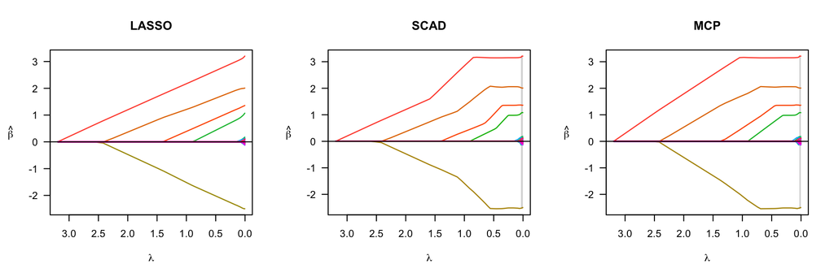

```r
par(mfrow = c(1, 3))
plot(fit_lasso, main = "LASSO")
plot(fit_scad,  main = "SCAD")
plot(fit_mcp,   main = "MCP")
```

## 2.4 Wybór $\lambda$ przez walidację krzyżową

`cv.ncvreg` automatycznie wybiera $\lambda$ minimalizujące błąd CV (domyślnie 10-krotny).

```r
cv_lasso <- cv.ncvreg(X, y, penalty = "lasso", seed = 2026)
cv_scad  <- cv.ncvreg(X, y, penalty = "SCAD",  seed = 2026)
cv_mcp   <- cv.ncvreg(X, y, penalty = "MCP",   seed = 2026)

cat("Optymalne lambda:\n")
```

```
Optymalne lambda:
```

```r
cat("  LASSO:", round(cv_lasso$lambda.min, 4), "\n")
```

```
  LASSO: 0.0976
```

```r
cat("  SCAD: ", round(cv_scad$lambda.min,  4), "\n")
```

```
  SCAD:  0.2102
```

```r
cat("  MCP:  ", round(cv_mcp$lambda.min,   4), "\n")
```

```
  MCP:   0.2592
```

## 2.5 Porównanie wybranych zmiennych

Wyciągamy wektor współczynników w optimum CV (`coef()` zwraca wyraz wolny + współczynniki).

```r
get_selected <- function(cv_fit) {
  b <- coef(cv_fit)         # wyraz wolny + 50 współczynników
  which(b[-1] != 0)         # indeksy niezerowych (pomijamy intercept)
}

sel_lasso <- get_selected(cv_lasso)
sel_scad  <- get_selected(cv_scad)
sel_mcp   <- get_selected(cv_mcp)

cat("Prawdziwe aktywne zmienne:", which_active, "\n")
```

```
Prawdziwe aktywne zmienne: 1 2 5 10 20
```

```r
cat("LASSO wybrał (", length(sel_lasso), "):", sel_lasso, "\n")
```

```
LASSO wybrał ( 8 ): 1 2 5 10 18 20 23 30
```

```r
cat("SCAD  wybrał (", length(sel_scad), "): ", sel_scad,  "\n")
```

```
SCAD  wybrał ( 5 ):  1 2 5 10 20
```

```r
cat("MCP   wybrał (", length(sel_mcp), "): ",  sel_mcp,   "\n")
```

```
MCP   wybrał ( 5 ):  1 2 5 10 20
```

```r
data.frame(
  metoda       = c("LASSO", "SCAD", "MCP"),
  n_wybranych  = c(length(sel_lasso), length(sel_scad), length(sel_mcp)),
  prawdziwe_TP = c(sum(which_active %in% sel_lasso),
                   sum(which_active %in% sel_scad),
                   sum(which_active %in% sel_mcp)),
  falszywe_FP  = c(sum(!sel_lasso %in% which_active),
                   sum(!sel_scad  %in% which_active),
                   sum(!sel_mcp   %in% which_active))
)
```

```
  metoda n_wybranych prawdziwe_TP falszywe_FP
1  LASSO           8            5           3
2   SCAD           5            5           0
3    MCP           5            5           0
```

# 3 Część B: Sztuczny przykład z próbami losową i nielosową

## 3.1 Generowanie populacji

Symulujemy populację $N = 10000$ z $p = 20$ ciągłymi zmiennymi pomocniczymi $\bx_i \sim N(0, 1)$. Zmienna $y$ zależy **tylko od pierwszych dwóch**:

$$y_i = 1 + 2\,x_{i,1} - 1{,}5\,x_{i,2} + \varepsilon_i, \quad \varepsilon_i \sim N(0, 1).$$

Średnia w populacji (do oszacowania):

$$\mu_y = E(y) \approx 1.$$

Mechanizm selekcji do próby nielosowej $S_A$ zależy z kolei **tylko od $x_3$ i $x_4$**:

$$P(R^A_i = 1 \mid \bx_i) = \frac{\exp(-2 + x_{i,3} - 0{,}5 x_{i,4})}{1 + \exp(-2 + x_{i,3} - 0{,}5 x_{i,4})}.$$

Pozostałe 16 zmiennych ($x_5, \ldots, x_{20}$) jest **nieistotne** – ani dla $y$, ani dla $R^A$.

```r
N <- 10000
p <- 20
X_pop <- matrix(rnorm(N*p), N, p)

# zmienna y zależy od x1, x2
y_pop <- 1 + 2*X_pop[,1] - 1.5*X_pop[,2] + rnorm(N)
mu_true <- mean(y_pop)

# prawdopodobieństwo włączenia do S_A zależy od x3, x4
eta <- -2 + X_pop[,3] - 0.5*X_pop[,4]
pi_A <- 1/(1 + exp(-eta))
R_A  <- rbinom(N, 1, pi_A)

# próba probabilistyczna S_B: SRS o liczebności n_B = 500
n_B <- 500
idx_B <- sample.int(N, n_B)

cat("Średnia w populacji mu_y:", round(mu_true, 3), "\n")
```

```
Średnia w populacji mu_y: 0.96
```

```r
cat("Liczebność S_A:", sum(R_A), "\n")
```

```
Liczebność S_A: 1715
```

```r
cat("Liczebność S_B:", n_B, "\n")
```

```
Liczebność S_B: 500
```

## 3.2 Przygotowanie danych

```r
S_A <- data.frame(X_pop[R_A == 1, ], y = y_pop[R_A == 1])
colnames(S_A) <- c(paste0("x", 1:p), "y")

S_B <- data.frame(X_pop[idx_B, ], d = N/n_B) # waga = N/n_B (SRS)
colnames(S_B) <- c(paste0("x", 1:p), "d")

# obiekt survey design dla S_B
sb_svy <- svydesign(ids = ~1, weights = ~d, data = S_B)
```

## 3.3 Naiwna średnia z próby nielosowej

Wprost z $S_A$, bez korekty – powinno być obciążone, bo zmienne $x_3, x_4$ wpływają zarówno na selekcję, jak i (poprzez korelację z $y$ – tu zerową, więc obciążenie wynika z selekcji warunkowej) na rozkład $y$ w próbie.

```r
mean(S_A$y)
```

```
[1] 1.042674
```

## 3.4 IPW z pełnym zestawem 20 zmiennych

```r
form_pelny <- as.formula(paste("~", paste0("x", 1:p, collapse = " + ")))
ipw_full <- nonprob(data      = S_A,
                    selection = form_pelny,
                    target    = ~ y,
                    svydesign = sb_svy,
                    method_selection = "logit")
ipw_full
```

```
A nonprob object
 - estimator type: inverse probability weighting
 - method: logit (mle)
 - IPW point estimator: Hajek (denominator: estimated IPW weights = 10103.4615)
 - auxiliary variables source: survey
 - vars selection: false
 - variance estimator: analytic
 - population size fixed: false
 - naive (uncorrected) estimator: 1.0427
 - selected estimator: 0.8356 (se=0.1849, ci=(0.4731, 1.1981))
```

## 3.5 IPW z doborem zmiennych (SCAD)

Włączamy `vars_selection = TRUE` w `control_inference` i wskazujemy karę SCAD w `control_selection`.

```r
ipw_scad <- nonprob(data      = S_A,
                    selection = form_pelny,
                    target    = ~ y,
                    svydesign = sb_svy,
                    method_selection = "logit",
                    control_inference = control_inf(vars_selection = TRUE),
                    control_selection = control_sel(penalty = "SCAD"))
ipw_scad
```

```
A nonprob object
 - estimator type: inverse probability weighting
 - method: logit (mle)
 - IPW point estimator: Hajek (denominator: estimated IPW weights = 10010.8387)
 - auxiliary variables source: survey
 - vars selection: true
 - variance estimator: analytic
 - population size fixed: false
 - naive (uncorrected) estimator: 1.0427
 - selected estimator: 0.9032 (se=0.1438, ci=(0.6213, 1.1851))
```

## 3.6 IPW z doborem zmiennych (MCP i LASSO)

```r
ipw_mcp <- nonprob(data      = S_A,
                   selection = form_pelny,
                   target    = ~ y,
                   svydesign = sb_svy,
                   method_selection = "logit",
                   control_inference = control_inf(vars_selection = TRUE),
                   control_selection = control_sel(penalty = "MCP"))

ipw_lasso <- nonprob(data      = S_A,
                     selection = form_pelny,
                     target    = ~ y,
                     svydesign = sb_svy,
                     method_selection = "logit",
                     control_inference = control_inf(vars_selection = TRUE),
                     control_selection = control_sel(penalty = "lasso"))
```

## 3.7 Porównanie – punktowe oszacowania i SE

```r
porownanie_b <- rbind(
  "IPW pełny model (20 zm.)" = extract(ipw_full),
  "IPW + SCAD"               = extract(ipw_scad),
  "IPW + MCP"                = extract(ipw_mcp),
  "IPW + LASSO"              = extract(ipw_lasso)
)
porownanie_b
```

```
                         target      mean         SE lower_bound upper_bound
IPW pełny model (20 zm.)      y 0.8356316 0.18494343   0.4731491    1.198114
IPW + SCAD                    y 0.9032087 0.14381316   0.6213401    1.185077
IPW + MCP                     y 1.1387347 0.03472463   1.0706757    1.206794
IPW + LASSO                   y 1.1387347 0.03472463   1.0706757    1.206794
```

```r
cat("\nPrawdziwa wartość mu_y =", round(mu_true, 3), "\n")
```

```
Prawdziwa wartość mu_y = 0.96
```

Zauważ, że **estymatory z doborem zmiennych** zwykle mają porównywalne lub mniejsze SE niż pełny model – bo wyrzucają z modelu zmienne niezwiązane z selekcją.

# 4 Część C: Realne dane `admin` i `jvs`

## 4.1 Wczytanie danych

```r
data(admin)
data(jvs)

# obiekt survey design dla S_B
jvs_svy <- svydesign(ids = ~ 1,
                     weights = ~ weight,
                     strata = ~ size + nace + region,
                     data = jvs)
```

Na surowych danych mamy tylko 4 zmienne (`size`, `nace`, `region`, `private`). Po zakodowaniu zmiennych kategorycznych przez dummies (`nace` ma kilka poziomów, `region` – kilkanaście) liczba kolumn w macierzy modelu jest dużo większa – i wtedy dobór zmiennych jest naprawdę użyteczny.

## 4.2 IPW z pełnym zestawem i z doborem zmiennych (SCAD)

```r
ipw_real_full <- nonprob(data      = admin,
                         selection = ~ size + nace + region + private,
                         target    = ~ single_shift,
                         svydesign = jvs_svy,
                         method_selection = "logit")
```

```r
ipw_real_scad <- nonprob(data      = admin,
                         selection = ~ size + nace + region + private,
                         target    = ~ single_shift,
                         svydesign = jvs_svy,
                         method_selection = "logit",
                         control_inference = control_inf(vars_selection = TRUE),
                         control_selection = control_sel(penalty = "SCAD"))
```

## 4.3 MI z doborem zmiennych

Dla masowej imputacji (model wynikowy) używamy `control_outcome` zamiast `control_selection`.

```r
mi_real_scad <- nonprob(data      = admin,
                        outcome   = single_shift ~ size + nace + region + private,
                        svydesign = jvs_svy,
                        method_outcome = "glm",
                        family_outcome = "binomial",
                        control_inference = control_inf(vars_selection = TRUE),
                        control_outcome  = control_out(penalty = "SCAD"))
```

## 4.4 DR z doborem zmiennych w obu modelach

Dla estymatora podwójnie odpornego selekcja odbywa się **niezależnie** w modelu PS i w modelu wynikowym. Końcowy zestaw zmiennych jest sumą obu (`vars_combine = TRUE` w nowszych wersjach pakietu).

```r
dr_real_scad <- nonprob(data      = admin,
                        selection = ~ size + nace + region + private,
                        outcome   = single_shift ~ size + nace + region + private,
                        svydesign = jvs_svy,
                        method_outcome = "glm",
                        family_outcome = "binomial",
                        control_inference = control_inf(vars_selection = TRUE),
                        control_selection = control_sel(penalty = "SCAD"),
                        control_outcome  = control_out(penalty = "SCAD"))
```

## 4.5 Porównanie – realne dane

```r
rbind(
  "IPW pełny"     = extract(ipw_real_full),
  "IPW + SCAD"    = extract(ipw_real_scad),
  "MI + SCAD"     = extract(mi_real_scad),
  "DR + SCAD"     = extract(dr_real_scad)
)
```

```
                 target      mean          SE lower_bound upper_bound
IPW pełny  single_shift 0.7083229 0.009436904   0.6898269   0.7268189
IPW + SCAD single_shift 0.6933108 0.008946616   0.6757757   0.7108458
MI + SCAD  single_shift 0.7027673 0.011244029   0.6807294   0.7248052
DR + SCAD  single_shift 0.7022786 0.010996903   0.6807250   0.7238321
```

# 5 Zadania do samodzielnego rozwiązania

## 5.1 Zadanie 1: ścieżki kar (dane sztuczne)

Wykorzystując dane z **Części A**:

1. Narysuj na jednym wykresie ścieżki współczynników dla LASSO i MCP (`plot(fit_lasso)` i `plot(fit_mcp)`). Co zauważasz w okolicy $\lambda$ bliskiego zeru?
2. Zmień rozmiar próby na $n = 1000$ (zachowując $p = 50$) i powtórz CV. Czy SCAD/MCP wybierają mniej zmiennych przy większej próbie?
3. Zwiększ szum: $\varepsilon \sim N(0, 4)$ zamiast $N(0, 1)$. Jak zmienia się liczba wybranych zmiennych?

## 5.2 Zadanie 2: dobór zmiennych w próbach (dane sztuczne)

Wykorzystując DGP z **Części B**, ale zmieniając go tak, że:

- $y$ zależy od $x_1, x_2, x_3$ (a nie tylko $x_1, x_2$),
- prawdopodobieństwo włączenia do $S_A$ zależy od $x_3, x_4$ (jak wcześniej).
1. Czyli $x_3$ jest teraz **prawdziwym czynnikiem zakłócającym** (związany z y i z R^A). Wygeneruj dane, dopasuj IPW + SCAD i IPW + LASSO. Czy obie kary zachowują $x_3$ w modelu?
2. Porównaj punktowe oszacowania z pełnym modelem (20 zmiennych) i prawdziwym $\mu_y$. Który estymator jest najbliżej prawdy?

## 5.3 Zadanie 3: MCP vs SCAD na realnych danych

Wykorzystując dane `admin` i `jvs`:

1. Dopasuj IPW z `penalty = "MCP"`, `selection = ~ size + nace + region + private`.
2. Porównaj liczbę niezerowych współczynników (`fit$coefficients`) między MCP i SCAD.
3. Czy oba dają zbliżone oszacowanie `single_shift`?

## 5.4 Zadanie 4: MI + LASSO vs MI bez selekcji

Wykorzystując dane `admin` i `jvs`:

1. Dopasuj MI (`single_shift ~ size + nace + region + private`, binomial) **bez** selekcji oraz z `penalty = "lasso"`.
2. Porównaj punktowe oszacowanie i SE. Czy SE jest mniejsze po selekcji?
3. Sprawdź, które zmienne zostały usunięte przez LASSO (porównaj nazwy w `coef(...)`).